# Model selection and Examination Tree-Based Models

Author

Guibril Ramde

## Exercise 8

**##Exercise 8.1**

```r
#install.packages('')
library(mlbench)
set.seed(200)
simulated <- mlbench.friedman1(200, sd = 1)
simulated <- cbind(simulated$x, simulated$y)
simulated <- as.data.frame(simulated)
colnames(simulated)[ncol(simulated)] <- "y"
```

a. Fit a random forest model to all of the predictors, then estimate the variable importance scores:

```r
library(randomForest)
library(caret)
model1 <- randomForest(y ~ ., data = simulated, importance = TRUE, ntree= 1000)
model1
```

```
Call:
 randomForest(formula = y ~ ., data = simulated, importance = TRUE,      ntree = 1000)
               Type of random forest: regression
                     Number of trees: 1000
No. of variables tried at each split: 3

          Mean of squared residuals: 6.514982
                    % Var explained: 73.28
```

```r
rfImp1 <- varImp(model1, scale = FALSE)
rfImp1
```

```
        Overall
V1   8.86329776
V2   6.72851763
V3   0.84145353
V4   7.60284159
V5   2.26864193
V6   0.11268425
V7   0.07374772
V8  -0.07210708
V9  -0.06913906
V10 -0.10577619
```

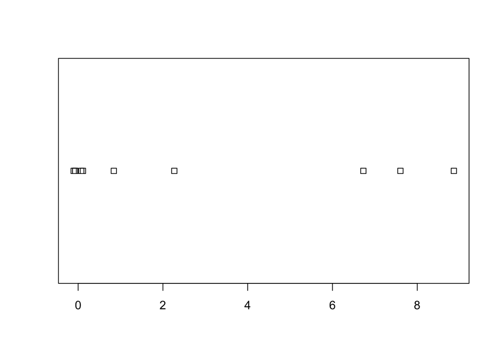

```r
plot(rfImp1)
```

Did the random forest model significantly use the uninformative predictors (V6 – V10)?

**##Answer:**

The random forest model used all ten predictors (V1–V10) to predict the response variable y. However, the variable importance scores for the uninformative predictors (V6–V10) were relatively low, with some values near zero or negative. This suggests that these predictors contributed little to the model’s predictive performance compared with the informative predictors (V1–V5). Therefore, the random forest did not rely heavily on the uninformative predictors.

b. Now add an additional predictor that is highly correlated with one of the informative predictors. For example:

```r
library(randomForest)
library(caret)

simulated2 <- simulated

set.seed(201)
simulated2$duplicate1 <- simulated2$V1 + rnorm(200) * 0.1

# Check correlation
cor(simulated2$duplicate1, simulated2$V1)
```

```
[1] 0.9358765
```

```r
# Fit a new random forest
set.seed(200)

model2 <- randomForest(
  y ~ .,
  data = simulated2,
  importance = TRUE,
  ntree = 1000
)

model2
```

```
Call:
 randomForest(formula = y ~ ., data = simulated2, importance = TRUE,      ntree = 1000)
               Type of random forest: regression
                     Number of trees: 1000
No. of variables tried at each split: 3

          Mean of squared residuals: 7.227598
                    % Var explained: 70.36
```

```r
# Variable importance
rfImp2 <- varImp(model2, scale = FALSE)

rfImp2
```

```
               Overall
V1          6.66784016
V2          5.94883839
V3          0.68183118
V4          7.05948117
V5          2.00197462
V6          0.17103674
V7          0.02785474
V8         -0.13644481
V9         -0.06659097
V10        -0.12343994
duplicate1  2.90167899
```

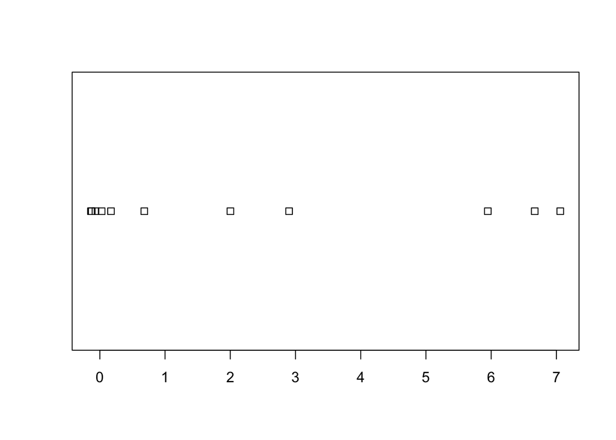

```r
plot(rfImp2)
```

Did the importance score for V1 change? What happens when you add another predictor that is also highly correlated with V1?

```r
# Create a third dataset
simulated3 <- simulated2

# Add another correlated predictor
set.seed(202)

simulated3$duplicate2 <- simulated3$V1 + rnorm(200) * 0.1

# Check correlations
cor(simulated3[, c("V1", "duplicate1", "duplicate2")])
```

```
                  V1 duplicate1 duplicate2
V1         1.0000000  0.9358765  0.9429382
duplicate1 0.9358765  1.0000000  0.8725834
duplicate2 0.9429382  0.8725834  1.0000000
```

```r
# Fit third random forest
set.seed(200)

model3 <- randomForest(
  y ~ .,
  data = simulated3,
  importance = TRUE,
  ntree = 1000
)

# Variable importance
rfImp3 <- varImp(model3, scale = FALSE)

rfImp3
```

```
                Overall
V1          4.895569743
V2          6.300210411
V3          0.440349997
V4          6.949353497
V5          2.062192732
V6          0.123605542
V7          0.031020095
V8         -0.068299597
V9         -0.009143988
V10         0.051067079
duplicate1  1.471278576
duplicate2  3.407370203
```

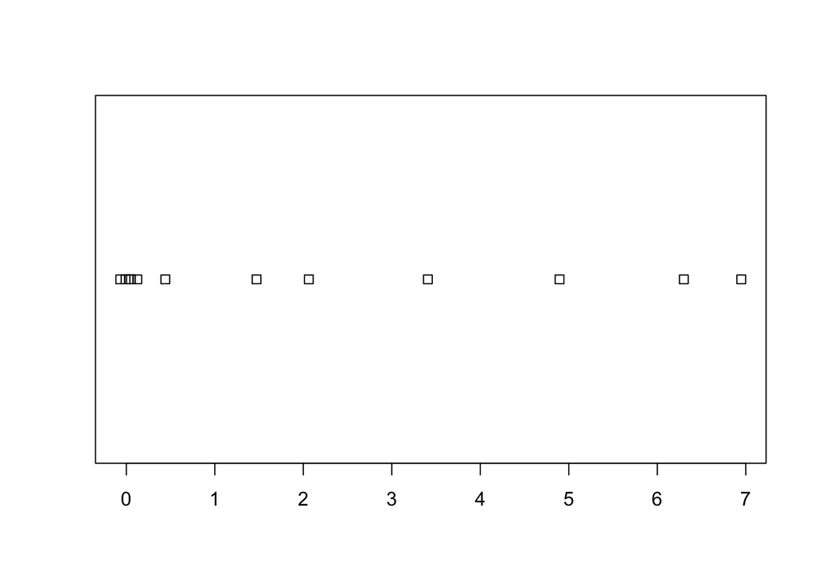

```r
plot(rfImp3)
```

```r
# Compare the importance of V1 across all three models
data.frame(
  Model = c("Model 1", "Model 2", "Model 3"),
  V1_Importance = c(
    rfImp1["V1", 1],
    rfImp2["V1", 1],
    rfImp3["V1", 1]
  )
)
```

```
    Model V1_Importance
1 Model 1      8.863298
2 Model 2      6.667840
3 Model 3      4.895570
```

**c. Use the cforest function in the party package to fit a random forest model using conditional inference trees.**

```r
library(party)
# Conditional inference forests
set.seed(200)
cforest1 <- cforest(y ~ ., data = simulated)

set.seed(200)
cforest2 <- cforest(y ~ ., data = simulated2)

set.seed(200)
cforest3 <- cforest(y ~ ., data = simulated3)

# Traditional permutation importance
imp1 <- varimp(cforest1, conditional = FALSE)
imp2 <- varimp(cforest2, conditional = FALSE)
imp3 <- varimp(cforest3, conditional = FALSE)

# Conditional permutation importance
cond_imp1 <- varimp(cforest1, conditional = TRUE)
cond_imp2 <- varimp(cforest2, conditional = TRUE)
cond_imp3 <- varimp(cforest3, conditional = TRUE)

# Compare V1 importance
comparison <- data.frame(
  Model = c("Model 1", "Model 2", "Model 3"),

  RandomForest = c(
    rfImp1["V1", 1],
    rfImp2["V1", 1],
    rfImp3["V1", 1]
  ),

  Cforest_Traditional = c(
    imp1["V1"],
    imp2["V1"],
    imp3["V1"]
  ),

  Cforest_Conditional = c(
    cond_imp1["V1"],
    cond_imp2["V1"],
    cond_imp3["V1"]
  )
)

comparison
```

```
    Model RandomForest Cforest_Traditional Cforest_Conditional
1 Model 1     8.863298            8.672661            5.604587
2 Model 2     6.667840            6.730145            3.135758
3 Model 3     4.895570            4.513619            1.707996
```

d. repeating with different tree model Boosted tree and Cubist tree

```r
##install.packages('gbm')
library(gbm)
# Model 1: Original predictors
set.seed(200)
gbmModel1 <- gbm(
  y ~ .,
  data = simulated,
  distribution = "gaussian",
  n.trees = 1000,
  interaction.depth = 3,
  shrinkage = 0.01,
  verbose = FALSE
)

# Model 2: One correlated predictor
set.seed(200)
gbmModel2 <- gbm(
  y ~ .,
  data = simulated2,
  distribution = "gaussian",
  n.trees = 1000,
  interaction.depth = 3,
  shrinkage = 0.01,
  verbose = FALSE
)

# Model 3: Two correlated predictors
set.seed(200)
gbmModel3 <- gbm(
  y ~ .,
  data = simulated3,
  distribution = "gaussian",
  n.trees = 1000,
  interaction.depth = 3,
  shrinkage = 0.01,
  verbose = FALSE
)
gbmImp1 <- summary(gbmModel1, plotit = FALSE)
gbmImp2 <- summary(gbmModel2, plotit = FALSE)
gbmImp3 <- summary(gbmModel3, plotit = FALSE)

gbmImp1
```

```
    var    rel.inf
V4   V4 28.3972578
V1   V1 26.6377714
V2   V2 21.9806150
V5   V5 11.7327317
V3   V3  7.6887939
V7   V7  1.0762463
V6   V6  0.9827406
V9   V9  0.5598912
V10 V10  0.5056136
V8   V8  0.4383385
```

```r
gbmImp2
```

```
                  var    rel.inf
V4                 V4 28.2530336
V1                 V1 23.8041343
V2                 V2 21.9286406
V5                 V5 11.7095916
V3                 V3  7.6446414
duplicate1 duplicate1  3.2524652
V7                 V7  1.0383308
V6                 V6  0.9291780
V9                 V9  0.5699957
V8                 V8  0.4785854
V10               V10  0.3914035
```

```r
gbmImp3
```

```
                  var    rel.inf
V4                 V4 27.7005475
V2                 V2 21.4361282
V1                 V1 17.4301682
V5                 V5 11.9205610
duplicate2 duplicate2  7.7537852
V3                 V3  7.4187733
duplicate1 duplicate1  2.9885001
V7                 V7  1.0343191
V6                 V6  0.8973513
V9                 V9  0.5342906
V8                 V8  0.5179416
V10               V10  0.3676339
```

```r
data.frame(
  Model = c("Model 1", "Model 2", "Model 3"),
  GBM_V1_Importance = c(
    gbmImp1$rel.inf[gbmImp1$var == "V1"],
    gbmImp2$rel.inf[gbmImp2$var == "V1"],
    gbmImp3$rel.inf[gbmImp3$var == "V1"]
  )
)
```

```
    Model GBM_V1_Importance
1 Model 1          26.63777
2 Model 2          23.80413
3 Model 3          17.43017
```

```r
library(Cubist)
# Model 1: Original predictors
set.seed(200)
cubistModel1 <- cubist(
  x = simulated[, setdiff(names(simulated), "y")],
  y = simulated$y,
  committees = 50
)

# Model 2: One correlated predictor
set.seed(200)
cubistModel2 <- cubist(
  x = simulated2[, setdiff(names(simulated2), "y")],
  y = simulated2$y,
  committees = 50
)

# Model 3: Two correlated predictors
set.seed(200)
cubistModel3 <- cubist(
  x = simulated3[, setdiff(names(simulated3), "y")],
  y = simulated3$y,
  committees = 50
)
cubistImp1 <- varImp(cubistModel1)
cubistImp2 <- varImp(cubistModel2)
cubistImp3 <- varImp(cubistModel3)

cubistImp1
```

```
    Overall
V1     71.0
V3     44.5
V2     57.5
V4     48.5
V5     35.0
V6      0.0
V7      0.0
V8      0.0
V9      0.0
V10     0.0
```

```r
cubistImp2
```

```
           Overall
V1            71.0
V3            43.0
V2            54.5
V4            48.0
V5            35.0
V6             0.0
V7             0.0
V8             0.0
V9             0.0
V10            0.0
duplicate1     0.0
```

```r
cubistImp3
```

```
           Overall
V3            45.0
V2            66.0
V1            57.5
V4            50.0
duplicate2    19.0
V5            33.0
V6            13.0
duplicate1     9.0
V7             0.0
V8             0.0
V9             0.0
V10            0.0
```

```r
data.frame(
  Model = c("Model 1", "Model 2", "Model 3"),
  Cubist_V1_Importance = c(
    cubistImp1["V1", 1],
    cubistImp2["V1", 1],
    cubistImp3["V1", 1]
  )
)
```

```
    Model Cubist_V1_Importance
1 Model 1                 71.0
2 Model 2                 71.0
3 Model 3                 57.5
```

```r
comparison_d <- data.frame(
  Model = c("Model 1", "Model 2", "Model 3"),

  GBM = c(
    gbmImp1$rel.inf[gbmImp1$var == "V1"],
    gbmImp2$rel.inf[gbmImp2$var == "V1"],
    gbmImp3$rel.inf[gbmImp3$var == "V1"]
  ),

  Cubist = c(
    cubistImp1["V1", 1],
    cubistImp2["V1", 1],
    cubistImp3["V1", 1]
  )
)

comparison_d
```

```
    Model      GBM Cubist
1 Model 1 26.63777   71.0
2 Model 2 23.80413   71.0
3 Model 3 17.43017   57.5
```

**##Exercise 8.2**

```r
#install.packages('rpart')
library(rpart)
library(dplyr)
library(rpart)
#library(rpart.plot)

set.seed(200)

n <- 200

simulated_tree <- data.frame(
  X1 = sample(1:2, n, replace = TRUE),
  X2 = sample(1:5, n, replace = TRUE),
  X3 = sample(1:20, n, replace = TRUE),
  X4 = runif(n)
)

# Response independent of all predictors
simulated_tree$y <- rnorm(n)

# Check the number of unique values
sapply(simulated_tree, function(x) length(unique(x)))
```

```
 X1  X2  X3  X4   y
  2   5  20 200 200
```

```r
tree_model <- rpart(
  y ~ .,
  data = simulated_tree,
  method = "anova",
  control = rpart.control(
    cp = 0,
    minsplit = 10
  )
)

#rpart.plot(tree_model)

tree_model$variable.importance
```

```
      X4       X3       X2       X1
61.26549 33.15347 17.50742  4.43626
```

```r
library(rpart)

set.seed(200)

results <- replicate(100, {

  simulated_tree <- data.frame(
    X1 = sample(1:2, 200, replace = TRUE),
    X2 = sample(1:5, 200, replace = TRUE),
    X3 = sample(1:20, 200, replace = TRUE),
    X4 = runif(200),
    y = rnorm(200)
  )

  tree_model <- rpart(
    y ~ .,
    data = simulated_tree,
    method = "anova",
    control = rpart.control(
      cp = 0,
      minsplit = 10,
      xval = 0
    )
  )

  as.character(tree_model$frame$var[1])
})

# Count how frequently each predictor was selected
table(factor(results, levels = c("X1", "X2", "X3", "X4")))
```

```
X1 X2 X3 X4
 3 10 24 63
```

## **Interpretation:**

The simulation shows how different predictor granularities can affect variable importance in a decision tree. All predictors have the same sample size of 200 observations, but they have different numbers of unique values. Predictors with more unique values provide more possible splitting points, which can cause the decision tree to assign them higher importance even when they are not related to the response variable. This demonstrates how decision trees can be biased toward predictors with higher granularity.

**Exercise 8.3**

**a. Why does the model on the right focus its importance on just the first few of predictors, whereas the model on the left spreads importance across more predictors?**

The model on the right focuses on fewer predictors because it uses a higher learning rate and bagging fraction. The higher learning rate allows the model to make larger adjustments, while the higher bagging fraction uses more observations to build each tree. As a result, the model concentrates importance on a few predictors. The model on the left uses smaller values, which spreads importance across more predictors.

**b. Which model do you think would be more predictive of other samples?**

I would expect the model on the left to perform better on new samples because it uses a lower learning rate, allowing the model to learn more gradually and potentially reduce overfitting. The model on the right makes larger adjustments, which may increase the risk of overfitting. However, we would need to compare their prediction errors on test data to determine which model performs better.

**c. How would increasing interaction depth affect the slope of predictor importance for either model in Fig. 8.24?**

Increasing the interaction depth allows the boosted trees to capture more complex relationships between predictors. This may spread variable importance across more predictors and produce a flatter importance curve. However, if a few predictors dominate the interactions, the importance scores may remain concentrated among those predictors.

8.7

```r
library(tidyverse)
library(AppliedPredictiveModeling)
library(caret)
library(earth)
library(kernlab)
library(nnet)
set.seed(42)

data(ChemicalManufacturingProcess)

# Dataset exploration
head(ChemicalManufacturingProcess)
```

```
  Yield BiologicalMaterial01 BiologicalMaterial02 BiologicalMaterial03
1 38.00                 6.25                49.58                56.97
2 42.44                 8.01                60.97                67.48
3 42.03                 8.01                60.97                67.48
4 41.42                 8.01                60.97                67.48
5 42.49                 7.47                63.33                72.25
6 43.57                 6.12                58.36                65.31
  BiologicalMaterial04 BiologicalMaterial05 BiologicalMaterial06
1                12.74                19.51                43.73
2                14.65                19.36                53.14
3                14.65                19.36                53.14
4                14.65                19.36                53.14
5                14.02                17.91                54.66
6                15.17                21.79                51.23
  BiologicalMaterial07 BiologicalMaterial08 BiologicalMaterial09
```

[output cut: 118 more lines]

```r
dim(ChemicalManufacturingProcess)
```

```
[1] 176  58
```

```r
str(ChemicalManufacturingProcess)
```

```
'data.frame':   176 obs. of  58 variables:
 $ Yield                 : num  38 42.4 42 41.4 42.5 ...
 $ BiologicalMaterial01  : num  6.25 8.01 8.01 8.01 7.47 6.12 7.48 6.94 6.94 6.94 ...
 $ BiologicalMaterial02  : num  49.6 61 61 61 63.3 ...
 $ BiologicalMaterial03  : num  57 67.5 67.5 67.5 72.2 ...
 $ BiologicalMaterial04  : num  12.7 14.7 14.7 14.7 14 ...
 $ BiologicalMaterial05  : num  19.5 19.4 19.4 19.4 17.9 ...
 $ BiologicalMaterial06  : num  43.7 53.1 53.1 53.1 54.7 ...
 $ BiologicalMaterial07  : num  100 100 100 100 100 100 100 100 100 100 ...
 $ BiologicalMaterial08  : num  16.7 19 19 19 18.2 ...
 $ BiologicalMaterial09  : num  11.4 12.6 12.6 12.6 12.8 ...
 $ BiologicalMaterial10  : num  3.46 3.46 3.46 3.46 3.05 3.78 3.04 3.85 3.85 3.85 ...
 $ BiologicalMaterial11  : num  138 154 154 154 148 ...
 $ BiologicalMaterial12  : num  18.8 21.1 21.1 21.1 21.1 ...
 $ ManufacturingProcess01: num  NA 0 0 0 10.7 12 11.5 12 12 12 ...
```

[output cut: 44 more lines]

```r
summary(ChemicalManufacturingProcess)
```

```
     Yield       BiologicalMaterial01 BiologicalMaterial02 BiologicalMaterial03
 Min.   :35.25   Min.   :4.580        Min.   :46.87        Min.   :56.97
 1st Qu.:38.75   1st Qu.:5.978        1st Qu.:52.68        1st Qu.:64.98
 Median :39.97   Median :6.305        Median :55.09        Median :67.22
 Mean   :40.18   Mean   :6.411        Mean   :55.69        Mean   :67.70
 3rd Qu.:41.48   3rd Qu.:6.870        3rd Qu.:58.74        3rd Qu.:70.43
 Max.   :46.34   Max.   :8.810        Max.   :64.75        Max.   :78.25

 BiologicalMaterial04 BiologicalMaterial05 BiologicalMaterial06
 Min.   : 9.38        Min.   :13.24        Min.   :40.60
 1st Qu.:11.24        1st Qu.:17.23        1st Qu.:46.05
 Median :12.10        Median :18.49        Median :48.46
 Mean   :12.35        Mean   :18.60        Mean   :48.91
 3rd Qu.:13.22        3rd Qu.:19.90        3rd Qu.:51.34
 Max.   :23.09        Max.   :24.85        Max.   :59.38

 BiologicalMaterial07 BiologicalMaterial08 BiologicalMaterial09
 Min.   :100.0        Min.   :15.88        Min.   :11.44
 1st Qu.:100.0        1st Qu.:17.06        1st Qu.:12.60
 Median :100.0        Median :17.51        Median :12.84
 Mean   :100.0        Mean   :17.49        Mean   :12.85
 3rd Qu.:100.0        3rd Qu.:17.88        3rd Qu.:13.13
 Max.   :100.8        Max.   :19.14        Max.   :14.08

 BiologicalMaterial10 BiologicalMaterial11 BiologicalMaterial12
 Min.   :1.770        Min.   :135.8        Min.   :18.35
 1st Qu.:2.460        1st Qu.:143.8        1st Qu.:19.73
 Median :2.710        Median :146.1        Median :20.12
 Mean   :2.801        Mean   :147.0        Mean   :20.20
 3rd Qu.:2.990        3rd Qu.:149.6        3rd Qu.:20.75
 Max.   :6.870        Max.   :158.7        Max.   :22.21

 ManufacturingProcess01 ManufacturingProcess02 ManufacturingProcess03
 Min.   : 0.00          Min.   : 0.00          Min.   :1.47
 1st Qu.:10.80          1st Qu.:19.30          1st Qu.:1.53
 Median :11.40          Median :21.00          Median :1.54
 Mean   :11.21          Mean   :16.68          Mean   :1.54
 3rd Qu.:12.15          3rd Qu.:21.50          3rd Qu.:1.55
 Max.   :14.10          Max.   :22.50          Max.   :1.60
 NA's   :1              NA's   :3              NA's   :15
```

[output cut: 96 more lines]

```
 ManufacturingProcess40 ManufacturingProcess41 ManufacturingProcess42
 Min.   :0.00000        Min.   :0.00000        Min.   : 0.00
 1st Qu.:0.00000        1st Qu.:0.00000        1st Qu.:11.40
 Median :0.00000        Median :0.00000        Median :11.60
 Mean   :0.01771        Mean   :0.02371        Mean   :11.21
 3rd Qu.:0.00000        3rd Qu.:0.00000        3rd Qu.:11.70
 Max.   :0.10000        Max.   :0.20000        Max.   :12.10
 NA's   :1              NA's   :1
 ManufacturingProcess43 ManufacturingProcess44 ManufacturingProcess45
 Min.   : 0.0000        Min.   :0.000          Min.   :0.000
 1st Qu.: 0.6000        1st Qu.:1.800          1st Qu.:2.100
 Median : 0.8000        Median :1.900          Median :2.200
 Mean   : 0.9119        Mean   :1.805          Mean   :2.138
 3rd Qu.: 1.0250        3rd Qu.:1.900          3rd Qu.:2.300
 Max.   :11.0000        Max.   :2.100          Max.   :2.600
```

```r
# Missing values
sum(is.na(ChemicalManufacturingProcess))
```

```
[1] 106
```

```r
colSums(is.na(ChemicalManufacturingProcess))
```

```
                 Yield   BiologicalMaterial01   BiologicalMaterial02
                     0                      0                      0
  BiologicalMaterial03   BiologicalMaterial04   BiologicalMaterial05
                     0                      0                      0
  BiologicalMaterial06   BiologicalMaterial07   BiologicalMaterial08
                     0                      0                      0
  BiologicalMaterial09   BiologicalMaterial10   BiologicalMaterial11
                     0                      0                      0
  BiologicalMaterial12 ManufacturingProcess01 ManufacturingProcess02
                     0                      1                      3
ManufacturingProcess03 ManufacturingProcess04 ManufacturingProcess05
                    15                      1                      1
ManufacturingProcess06 ManufacturingProcess07 ManufacturingProcess08
                     2                      1                      1
ManufacturingProcess09 ManufacturingProcess10 ManufacturingProcess11
                     0                      9                     10
ManufacturingProcess12 ManufacturingProcess13 ManufacturingProcess14
                     1                      0                      1
ManufacturingProcess15 ManufacturingProcess16 ManufacturingProcess17
                     0                      0                      0
ManufacturingProcess18 ManufacturingProcess19 ManufacturingProcess20
                     0                      0                      0
ManufacturingProcess21 ManufacturingProcess22 ManufacturingProcess23
                     0                      1                      1
ManufacturingProcess24 ManufacturingProcess25 ManufacturingProcess26
                     1                      5                      5
ManufacturingProcess27 ManufacturingProcess28 ManufacturingProcess29
                     5                      5                      5
ManufacturingProcess30 ManufacturingProcess31 ManufacturingProcess32
                     5                      5                      0
ManufacturingProcess33 ManufacturingProcess34 ManufacturingProcess35
                     5                      5                      5
ManufacturingProcess36 ManufacturingProcess37 ManufacturingProcess38
                     5                      0                      0
ManufacturingProcess39 ManufacturingProcess40 ManufacturingProcess41
                     0                      1                      1
ManufacturingProcess42 ManufacturingProcess43 ManufacturingProcess44
                     0                      0                      0
ManufacturingProcess45
                     0
```

```r
# Remove observations with missing response
model_data <- ChemicalManufacturingProcess |>
  filter(!is.na(Yield))

set.seed(42)

train_index <- createDataPartition(
  model_data$Yield,
  p = 0.80,
  list = FALSE
)

train_data <- model_data[train_index, , drop = FALSE]
test_data <- model_data[-train_index, , drop = FALSE]

# Preprocessing
preprocess_model <- preProcess(
  train_data |> select(-Yield),
  method = c("medianImpute", "center", "scale")
)

x_train <- predict(
  preprocess_model,
  train_data |> select(-Yield)
)

x_test <- predict(
  preprocess_model,
  test_data |> select(-Yield)
)

train_processed <- bind_cols(
  tibble(Yield = train_data$Yield),
  as_tibble(x_train)
)

test_processed <- bind_cols(
  tibble(Yield = test_data$Yield),
  as_tibble(x_test)
)

# Check results
dim(train_processed)
```

```
[1] 144  58
```

```r
dim(test_processed)
```

```
[1] 32 58
```

```r
sum(is.na(train_processed))
```

```
[1] 0
```

```r
sum(is.na(test_processed))
```

```
[1] 0
```

```r
library(caret)
library(rpart)
library(randomForest)
library(gbm)
library(Cubist)
library(party)

# Same resampling method
set.seed(200)

ctrl <- trainControl(
  method = "cv",
  number = 10,
  savePredictions = "final"
)

# Regression tree
set.seed(200)
cart_model <- train(
  Yield ~ .,
  data = train_processed,
  method = "rpart",
  trControl = ctrl,
  tuneLength = 10
)
# Random forest
set.seed(200)
rf_model <- train(
  Yield ~ .,
  data = train_processed,
  method = "rf",
  trControl = ctrl,
  tuneLength = 5,
  ntree = 1000
)

# Boosted trees
set.seed(200)
gbm_model <- train(
  Yield ~ .,
  data = train_processed,
  method = "gbm",
  trControl = ctrl,
  tuneLength = 5,
  verbose = FALSE
)

# Cubist
# Separate predictors and response
x_train <- train_processed |>
  select(-Yield) |>
  as.data.frame()

y_train <- train_processed$Yield

# Verify
class(x_train)
```

```
[1] "data.frame"
```

```r
class(y_train)
```

```
[1] "numeric"
```

```r
# Fit Cubist
set.seed(200)

cubist_model <- train(
  x = x_train,
  y = y_train,
  method = "cubist",
  trControl = ctrl,
  tuneLength = 5
)

cubist_model
```

```
Cubist

144 samples
 57 predictor

No pre-processing
Resampling: Cross-Validated (10 fold)
Summary of sample sizes: 130, 129, 129, 130, 131, 131, ...
Resampling results across tuning parameters:

  committees  neighbors  RMSE      Rsquared   MAE
   1          0          1.735790  0.4413753  1.2179269
   1          5          1.582588  0.5499179  1.0668288
   1          9          1.645473  0.5028669  1.1169141
  10          0          1.158436  0.5886756  0.9400021
  10          5          1.040224  0.6697810  0.8314036
  10          9          1.074680  0.6437898  0.8579826
  20          0          1.118389  0.6175767  0.9021613
  20          5          1.007256  0.6915112  0.8018895
  20          9          1.040483  0.6673778  0.8241642

RMSE was used to select the optimal model using the smallest value.
The final values used for the model were committees = 20 and neighbors = 5.
```

```r
# Conditional inference tree
set.seed(200)
ctree_model <- train(
  Yield ~ .,
  data = train_processed,
  method = "ctree",
  trControl = ctrl,
  tuneLength = 5
)
```

```r
results <- resamples(
  list(
    CART = cart_model,
    RF = rf_model,
    GBM = gbm_model,
    Cubist = cubist_model,
    CTree = ctree_model
  )
)

summary(results)
```

```
Call:
summary.resamples(object = results)

Models: CART, RF, GBM, Cubist, CTree
Number of resamples: 10

MAE
            Min.   1st Qu.    Median      Mean   3rd Qu.     Max. NA's
CART   0.7193020 1.0666906 1.2200787 1.1778999 1.3310017 1.539486    0
RF     0.4786234 0.6672862 0.9401144 0.8561532 1.0284428 1.206007    0
GBM    0.5853965 0.6971122 0.8527824 0.8274906 0.9333039 1.076002    0
Cubist 0.4708544 0.6577201 0.8635086 0.8018895 0.9226732 1.044647    0
CTree  0.6155495 0.9893697 1.1895246 1.1881499 1.4020487 1.793866    0

RMSE
            Min.   1st Qu.   Median     Mean  3rd Qu.     Max. NA's
CART   0.9112750 1.3128026 1.537560 1.480402 1.668496 1.856052    0
RF     0.5845038 0.8910123 1.198280 1.109493 1.270006 1.725238    0
GBM    0.8204959 0.9177231 1.076479 1.068098 1.236501 1.321217    0
Cubist 0.6041534 0.8300363 1.058250 1.007256 1.184712 1.284616    0
CTree  0.7226186 1.1882544 1.451357 1.447584 1.605547 2.413296    0

Rsquared
             Min.   1st Qu.    Median      Mean   3rd Qu.      Max. NA's
CART   0.07009737 0.3848740 0.4285589 0.4036575 0.5011280 0.7336325    0
RF     0.26589999 0.5562021 0.6798057 0.6430271 0.7910120 0.9163950    0
GBM    0.40396688 0.6362956 0.6883401 0.6532606 0.7209765 0.8342853    0
Cubist 0.41685790 0.6194127 0.7496965 0.6915112 0.8101867 0.8533850    0
CTree  0.07691661 0.1957385 0.4067542 0.3948990 0.5605886 0.7682798    0
```

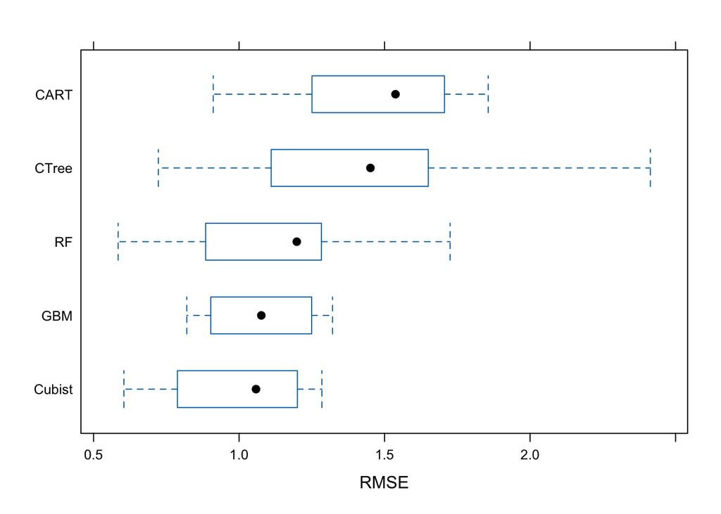

```r
bwplot(results, metric = "RMSE")
```

```r
library(dplyr)

models <- list(
  CART = cart_model,
  RF = rf_model,
  GBM = gbm_model,
  Cubist = cubist_model,
  CTree = ctree_model
)

test_results <- lapply(names(models), function(name) {

  predictions <- predict(models[[name]], newdata = test_processed)

  data.frame(
    Model = name,
    RMSE = RMSE(predictions, test_processed$Yield),
    Rsquared = R2(predictions, test_processed$Yield),
    MAE = MAE(predictions, test_processed$Yield)
  )
}) |>
  bind_rows() |>
  arrange(RMSE)

test_results
```

```
   Model      RMSE  Rsquared       MAE
1 Cubist 0.9540283 0.7949420 0.7306373
2     RF 1.1563687 0.7497949 0.8483462
3    GBM 1.2413309 0.6482784 0.9532315
4   CART 1.5027045 0.4561721 1.1069728
5  CTree 1.5874339 0.3709582 1.1280027
```

## **Interpretation:**

The Cubist regression model showed the best overall test performance among the five tree-based models, with the lowest RMSE of 0.9540, MAE of 0.7306, and highest R² of 0.7949. Random Forest was the second-best model on the test set, followed by GBM, CART, and CTree. The cross-validation plot also showed that Cubist and GBM had relatively low prediction errors. Overall, Cubist appears to be the optimal tree-based model for predicting manufacturing Yield.

b. Identify the most important predictors

```r
cubist_importance <- varImp(cubist_model, scale = FALSE)

cubist_importance
```

```
cubist variable importance

  only 20 most important variables shown (out of 57)

                       Overall
ManufacturingProcess32    52.5
ManufacturingProcess09    35.0
ManufacturingProcess17    30.0
BiologicalMaterial06      19.0
ManufacturingProcess04    18.0
ManufacturingProcess33    16.5
ManufacturingProcess29    16.0
ManufacturingProcess45    13.0
ManufacturingProcess39    12.5
ManufacturingProcess27    12.0
BiologicalMaterial03      12.0
ManufacturingProcess13    10.5
BiologicalMaterial12      10.0
BiologicalMaterial02       9.5
ManufacturingProcess25     8.5
ManufacturingProcess05     6.5
ManufacturingProcess01     6.5
ManufacturingProcess11     6.5
ManufacturingProcess31     5.5
ManufacturingProcess37     5.5
```

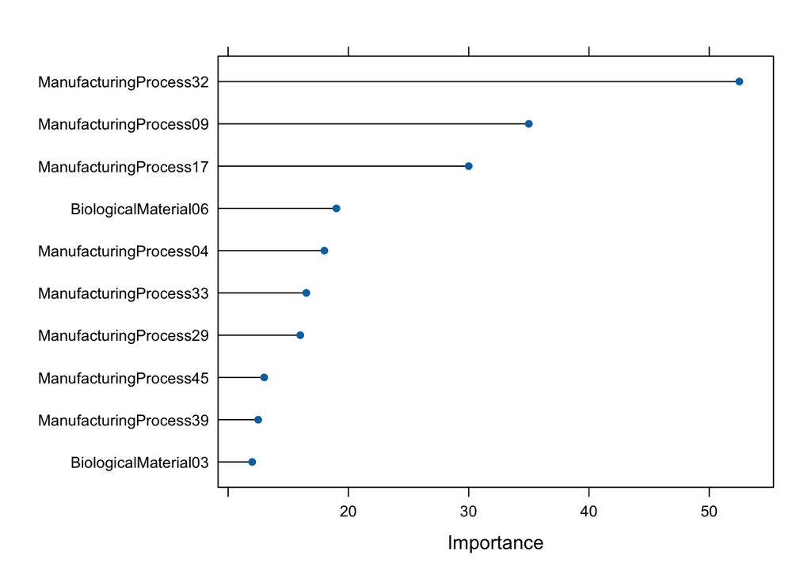

```r
plot(cubist_importance, top = 10)
```

```r
top10_tree <- cubist_importance$importance |>
  tibble::rownames_to_column("Predictor") |>
  arrange(desc(Overall)) |>
  slice_head(n = 10)

top10_tree
```

```
                Predictor Overall
1  ManufacturingProcess32    52.5
2  ManufacturingProcess09    35.0
3  ManufacturingProcess17    30.0
4    BiologicalMaterial06    19.0
5  ManufacturingProcess04    18.0
6  ManufacturingProcess33    16.5
7  ManufacturingProcess29    16.0
8  ManufacturingProcess45    13.0
9  ManufacturingProcess39    12.5
10   BiologicalMaterial03    12.0
```

## **Interpretation:**

The Cubist model identified ManufacturingProcess32, ManufacturingProcess09, and ManufacturingProcess17 as the three most important predictors, with importance scores of 52.5, 35.0, and 30.0, respectively. Among the top 10 predictors, eight were manufacturing process variables and two were biological material variables. This suggests that manufacturing process variables play a major role in predicting Yield in the Cubist model. However, biological material variables also contribute to the prediction.

```r
library(dplyr)

# Import results from previous exercises
top10_linear <- read.csv("ridge_top10.csv")
top10_nonlinear <- read.csv("svm_top10.csv")

# Cubist vs Ridge
common_linear <- intersect(
  top10_tree$Predictor,
  top10_linear$Predictor
)

# Cubist vs SVM Radial
common_nonlinear <- intersect(
  top10_tree$Predictor,
  top10_nonlinear$Variable
)

common_linear
```

```
[1] "ManufacturingProcess32" "ManufacturingProcess09" "ManufacturingProcess17"
[4] "ManufacturingProcess33" "BiologicalMaterial03"
```

```r
common_nonlinear
```

```
[1] "ManufacturingProcess32" "ManufacturingProcess09" "ManufacturingProcess17"
[4] "BiologicalMaterial03"
```

**c. Plot the optimal**

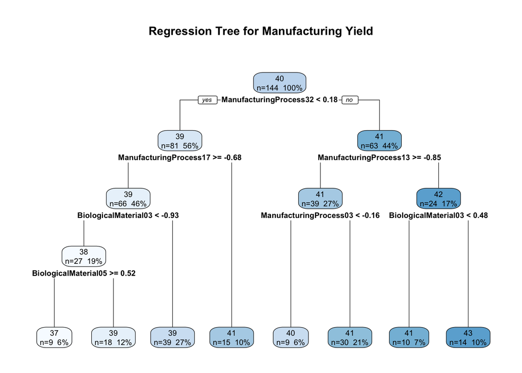

```r
#install.packages('rpart.plot')
library(rpart.plot)
rpart.plot(
  cart_model$finalModel,
  #cubist_model$finalModel,
  type = 2,
  extra = 101,
  fallen.leaves = TRUE,
  main = "Regression Tree for Manufacturing Yield"
)
```

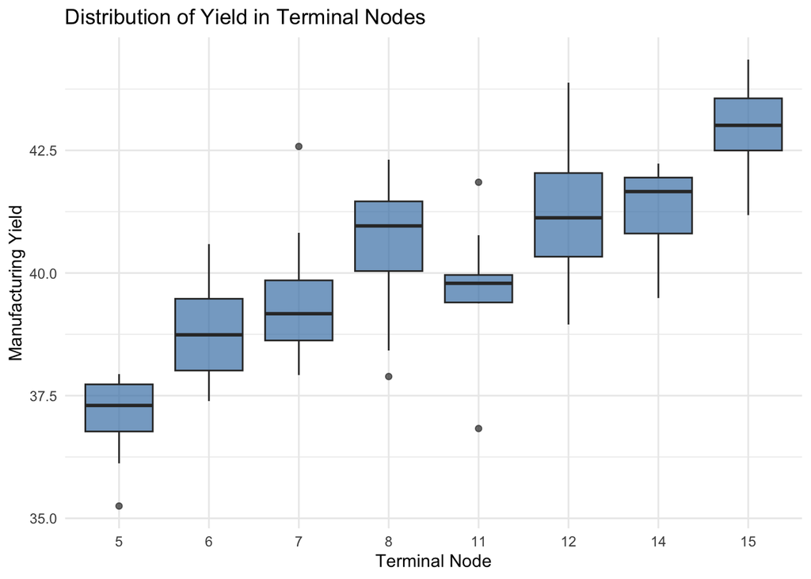

```r
library(ggplot2)

node_data <- data.frame(
  Yield = train_processed$Yield,
  Node = factor(cart_model$finalModel$where)
)

ggplot(node_data, aes(x = Node, y = Yield)) +
  geom_boxplot(fill = "steelblue", alpha = 0.7) +
  labs(
    title = "Distribution of Yield in Terminal Nodes",
    x = "Terminal Node",
    y = "Manufacturing Yield"
  ) +
  theme_minimal()
```

## **Interpretation:**

Yes, the regression tree provides additional information about the relationships between biological material, manufacturing process predictors, and Yield. ManufacturingProcess32 is the first splitting variable, suggesting that it plays an important role in predicting Yield. Other process variables, including ManufacturingProcess17, ManufacturingProcess13, and ManufacturingProcess03, also contribute to the tree, while BiologicalMaterial03 and BiologicalMaterial05 indicate that biological characteristics are important as well.

The terminal-node boxplot shows that Yield differs across groups of observations. Node 5 has the lowest median Yield of approximately 37.3, while Node 15 has the highest median Yield of approximately 43.0. This suggests that certain combinations of biological and manufacturing process conditions are associated with higher manufacturing yields.

Overall, the regression tree provides additional insight by showing how different predictors interact to separate observations into groups with different Yield levels. However, these relationships are associations and do not necessarily indicate causation.